# Práctica 05: Colgate vs Crest

Práctica 05: Colgate vs Crest Ignacio Ruiz de Zuazu Echevarría 22/11/2020

[link a GitHub](https://github.com/ignacio-ruiz-de-zuazu/Prediccion-practicas.git)

[figure not shown]

## Objetivo del trabajo

El objetivo es predecir las 16 semanas del año 1963, para las dos cuotas de mercado, por lo que se dejará fuera de la muestra este periodo muestral.

El análisis debe incluir para las dos series la estimación de un modelo ARIMA, la detección de atípicos/outlier y un modelo de interveción. Por último se debe realizar un modelo de función de tranferencia entre las dos cuotas.

## Librerías

```r
library(openxlsx)
library(xts)
library(TSA)
library(ggplot2)
library(forecast)
library(zoo)
library(here)
library(tsoutliers)
library(lmtest)
```

## Dataset

```
##   Year Week Crest Colgate
## 1 1958    1 0.108   0.424
## 2 1958    2 0.166   0.482
## 3 1958    3 0.126   0.428
## 4 1958    4 0.115   0.397
## 5 1958    5 0.119   0.352
## 6 1958    6 0.176   0.342
```

El dataset se compone por 276 observaciones y 4 variables, de las cuales dos corresponden a las cuotas de mercado de Colgate y Crest, ambas dedicadas al sector dentrífico. El resto de variables correponden al periodo temporal de cada cuota de mercado alcanzada separada por el año y la semana. Estas dos variables, habrá que modificarlas para realizar el análisis.

## Exploración de los datos

En este dataset se ha comprobado que no existe ningún tipo de valor perdido en las series temporales.

```
## [1] 0
```

## Gráficas de las series temporales

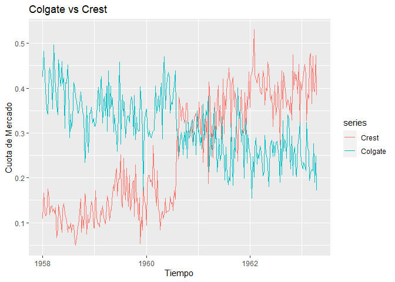

En esta gráfica se muestra la evolución temporal de las cuotas de mercado tanto de Colgate como de Crest. De la misma forma podemos apreciar una primera comparación de ambas series. Se observa una tendencia general creciente en la serie de Crest durante los años, especialmente en 1960 donde además no parece haber una estacionalidad aunque más adelante se realizará un estudio de esta. Por otro lado, Colgate, tiene una tendencia bajista en cuanto a su cotización a diferencia de lo que veíamos con Crest, incluso se podrá decir que en el 1960 donde Crest tuvo un pico alto en cuanto a su cotización, Colgate sufrió una bajada. También se puede comentar a priori que las cotizaciones de Crest no parecen estacionarias a diferencia de Colgate donde se podría decir que la serie es un poco más estacionaria o que oscila sobre una media.

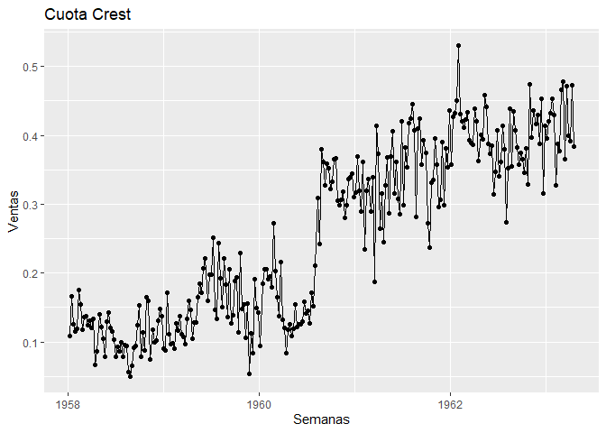

Por una parte, si observamos las series por separadas, podemos ver que en cuanto a Crest, ésta tiene una tendencia alcista y vemos que hay un escalón en 1960 puesto que las medias de las cotizaciones no vuleven a los valores iniciales. Este escalón probablemente se debió a un hecho que ocurrió en ese instante de tiempo. Comparando con el gráfico anterior podemos ver que Crest tuvo una fuerte posición en el mercado de dentríficos durante estos años.

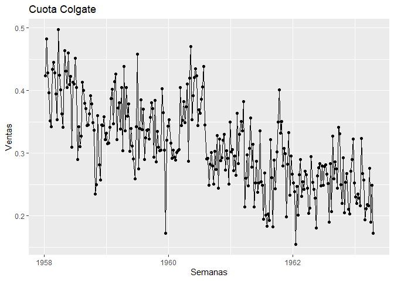

Por otra parte, Colgate, tiene un tendencia bajista a lo largo de los años sin una aparente estacionalidad. Como se puede observar tambien en este gráfico a parte de la ausencia de estacionariedad, podemos decir que tampoco tiene estacionalidad por que la cuota de mercado no se ve afectada por el mes en el que nos encontremos. Nuestra serie temporal es no estacionaria en media cuando tiene tendencia creciente o decreciente o cambios de nivel.

## Modelo Arima

Como parte de los subobjetivos del análisis se procede a realizar los Modelos ARIMA para ambas marcas. Para ello, hay que convertir las variables a tipo zoo para poder realizar las predicciones.

### Modelo ARIMA para Colgate

```
## Series: ocolgate
## ARIMA(0,1,1)
##
## Coefficients:
##           ma1
##       -0.7586
## s.e.   0.0467
##
## sigma^2 estimated as 0.002312:  log likelihood=418.57
## AIC=-833.14   AICc=-833.09   BIC=-826.02
##
## Training set error measures:
##                        ME       RMSE       MAE       MPE     MAPE      MASE
## Training set -0.002603891 0.04790139 0.0377572 -3.050317 12.79113 0.1188498
##                    ACF1
## Training set 0.05192333
```

Obtenemos un modelo ARIMA en ambas series de orden (0,1,1). Es un modelo conocido como suavizado exponencial simple, en el cual, es mejor en vez de tomar la última media como único dato, tomar el promedio de las últimas observaciones para filtrar el ruido y estimar con mayor precisión la media local. El pronóstico de suavización exponencial simple es óptimo para patrones de demanda aleatorios o nivelados donde se pretende eliminar el impacto de los elementos irregulares históricos mediante un enfoque en períodos de demanda reciente para lograr óptimos resultados.

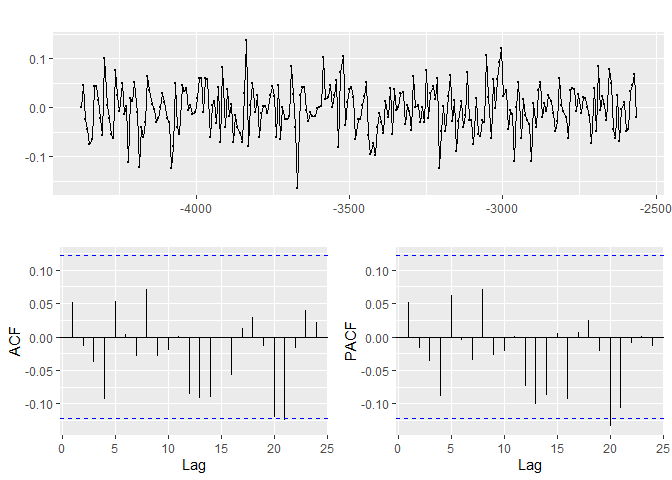

```
##
##  Box-Ljung test
##
## data:  modelo_arima_colgate$residuals
## X-squared = 1.1657, df = 0, p-value < 2.2e-16
```

```
##
##  Box-Ljung test
##
## data:  modelo_arima_colgate$residuals
## X-squared = 5.8268, df = 5, p-value = 0.3234
```

```
##
##  Box-Ljung test
##
## data:  modelo_arima_colgate$residuals
## X-squared = 8.202, df = 9, p-value = 0.5139
```

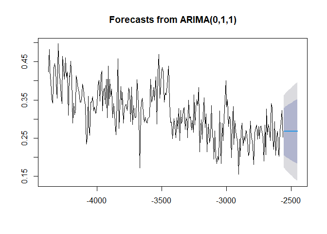

```
##
## Forecast method: ARIMA(0,1,1)
##
## Model Information:
## Series: ocolgate
## ARIMA(0,1,1)
##
## Coefficients:
##           ma1
##       -0.7586
## s.e.   0.0467
##
## sigma^2 estimated as 0.002312:  log likelihood=418.57
## AIC=-833.14   AICc=-833.09   BIC=-826.02
##
## Error measures:
##                        ME       RMSE       MAE       MPE     MAPE      MASE
## Training set -0.002603891 0.04790139 0.0377572 -3.050317 12.79113 0.1188498
##                    ACF1
## Training set 0.05192333
##
## Forecasts:
##       Point Forecast     Lo 80     Hi 80     Lo 95     Hi 95
## -2556      0.2675214 0.2058958 0.3291470 0.1732732 0.3617696
## -2549      0.2675214 0.2041258 0.3309169 0.1705663 0.3644765
## -2542      0.2675214 0.2024040 0.3326388 0.1679329 0.3671099
## -2535      0.2675214 0.2007265 0.3343163 0.1653674 0.3696754
## -2528      0.2675214 0.1990901 0.3359527 0.1628647 0.3721780
## -2521      0.2675214 0.1974919 0.3375508 0.1604206 0.3746222
## -2514      0.2675214 0.1959294 0.3391133 0.1580309 0.3770118
## -2507      0.2675214 0.1944003 0.3406425 0.1556924 0.3793504
## -2500      0.2675214 0.1929025 0.3421402 0.1534017 0.3816411
## -2493      0.2675214 0.1914342 0.3436085 0.1511561 0.3838867
## -2486      0.2675214 0.1899937 0.3450491 0.1489531 0.3860897
## -2479      0.2675214 0.1885795 0.3464633 0.1467902 0.3882526
## -2472      0.2675214 0.1871902 0.3478526 0.1446654 0.3903774
## -2465      0.2675214 0.1858245 0.3492183 0.1425767 0.3924660
## -2458      0.2675214 0.1844812 0.3505616 0.1405224 0.3945204
## -2451      0.2675214 0.1831594 0.3518834 0.1385008 0.3965420
```

```
##       Point Forecast     Lo 80     Hi 80     Lo 95     Hi 95
## -2556      0.2675214 0.2058958 0.3291470 0.1732732 0.3617696
## -2549      0.2675214 0.2041258 0.3309169 0.1705663 0.3644765
## -2542      0.2675214 0.2024040 0.3326388 0.1679329 0.3671099
## -2535      0.2675214 0.2007265 0.3343163 0.1653674 0.3696754
## -2528      0.2675214 0.1990901 0.3359527 0.1628647 0.3721780
## -2521      0.2675214 0.1974919 0.3375508 0.1604206 0.3746222
```

### Modelo Arima: Crest

```
## Series: ocrest
## ARIMA(0,1,1)
##
## Coefficients:
##           ma1
##       -0.6494
## s.e.   0.0448
##
## sigma^2 estimated as 0.002054:  log likelihood=434.08
## AIC=-864.15   AICc=-864.1   BIC=-857.04
##
## Training set error measures:
##                       ME       RMSE        MAE       MPE     MAPE      MASE
## Training set 0.003018071 0.04514444 0.03445351 -2.924537 17.27068 0.1405405
##                     ACF1
## Training set -0.04605961
```

Al igual que ocurría con Colgate, obtenemos un modelo ARIMA en ambas series de orden (0,1,1), también llamado modelo suavizado exponencial.

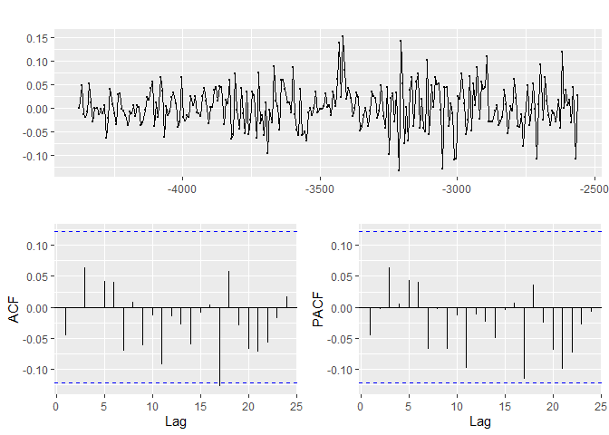

```
##
##  Box-Ljung test
##
## data:  modelo_arima_crest$residuals
## X-squared = 1.6314, df = 0, p-value < 2.2e-16
```

```
##
##  Box-Ljung test
##
## data:  modelo_arima_crest$residuals
## X-squared = 3.8799, df = 5, p-value = 0.5668
```

```
##
##  Box-Ljung test
##
## data:  modelo_arima_crest$residuals
## X-squared = 7.3979, df = 9, p-value = 0.5958
```

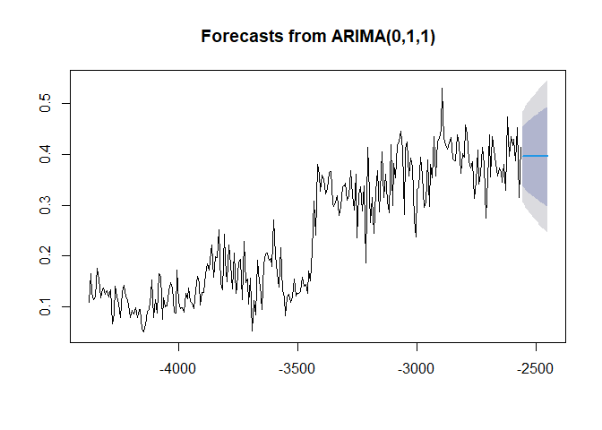

## Outliers detectados

Ahora vamos a proceder analizar los outliers tanto aditivos(afectan a la serie temporal) e innovativos(afectan al error) entonces vamos a analizar, los outliers para ambas compañías.

```
## [1] "No AO detected"
```

```
##               [,1]       [,2]       [,3]
## ind     135.000000 136.000000 138.000000
## lambda2   3.918954   4.372891   4.005427
```

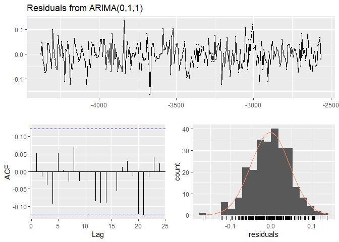

```
##
##  Ljung-Box test
##
## data:  Residuals from ARIMA(0,1,1)
## Q* = 6.1626, df = 9, p-value = 0.7235
##
## Model df: 1.   Total lags used: 10
```

Los valores atípicos AO son aquellos valores que afectan negativamente a nuestra serie temporal. En este caso, los valores atípicos que afectan a neustra serie son las semanas 135, 136 y 138 principalmente en la serie de Crest. Se podría decir que en esas semanas, Crest sufrió ese cambió que le permitió aumentar su cotización. Se observa también que los residuos siguen una distribución normal.

```
## [1] "No IO detected"
```

```
## [1] "No IO detected"
```

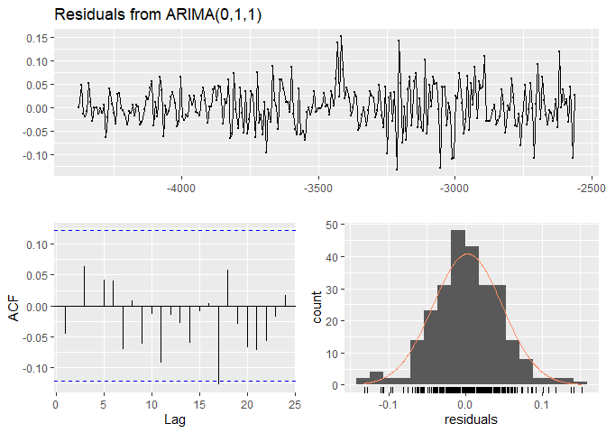

```
##
##  Ljung-Box test
##
## data:  Residuals from ARIMA(0,1,1)
## Q* = 4.9754, df = 9, p-value = 0.8364
##
## Model df: 1.   Total lags used: 10
```

En ambas series no se han detectado valores atípico que puedan llegar a afectar al error de las series (IO). De la misma forma para estos valores, los residuos siguen una distribución normal.

## Modelo de Intervención

Con este modelo vamos a tratar de ver la importancia de la decisión de la ADA

```
##
## z test of coefficients:
##
##            Estimate Std. Error  z value  Pr(>|z|)
## ma1       -0.804825   0.043637 -18.4437 < 2.2e-16 ***
## first-MA0 -0.101544   0.027859  -3.6449 0.0002675 ***
## ---
## Signif. codes:  0 '***' 0.001 '**' 0.01 '*' 0.05 '.' 0.1 ' ' 1
```

```
##
## z test of coefficients:
##
##              Estimate Std. Error  z value  Pr(>|z|)
## ma1         -0.744474   0.049265 -15.1117 < 2.2e-16 ***
## error136     0.022461   0.043176   0.5202   0.60290
## error138     0.076833   0.041428   1.8546   0.06365 .
## primero-MA0  0.133593   0.032689   4.0868 4.373e-05 ***
## ---
## Signif. codes:  0 '***' 0.001 '**' 0.01 '*' 0.05 '.' 0.1 ' ' 1
```

Ahora realizamos el test de los coeficientes, en ambos casos la observación 135, que hemos mostrado anteriormente por la detección de outliers, tiene una significatividad alta, y por tanto será este el valor de corte en nuestro modelo de intervención.

## Función de Transferencia

Se realiza una función de transferencia donde tanto de Crest como de Colgate tomamos los 134 primeros valores ya que a partir del 135, nuestra fecha de intervención, los valores empiezan a cambiar para ambas series. También se les aplicará una diferencia regular ya que es necesario arreglar el problema de la estacionalidad.

```
##
## z test of coefficients:
##
##           Estimate Std. Error  z value  Pr(>|z|)
## ma1     -0.9999995  0.0214756 -46.5645 < 2.2e-16 ***
## T1-MA0  -0.5329365  0.1553428  -3.4307  0.000602 ***
## T1-MA1   0.0075869  0.1852828   0.0409  0.967338
## T1-MA2  -0.0431039  0.2016641  -0.2137  0.830749
## T1-MA3   0.1526312  0.2077696   0.7346  0.462573
## T1-MA4   0.0105404  0.2072262   0.0509  0.959434
## T1-MA5  -0.1105735  0.2041136  -0.5417  0.588008
## T1-MA6   0.0390328  0.2036775   0.1916  0.848024
## T1-MA7  -0.1783823  0.2003697  -0.8903  0.373323
## T1-MA8   0.0547611  0.2004141   0.2732  0.784669
## T1-MA9  -0.1667349  0.2022635  -0.8243  0.409743
## T1-MA10  0.0749276  0.2031027   0.3689  0.712191
## T1-MA11  0.2016599  0.2061440   0.9782  0.327952
## T1-MA12  0.0762681  0.2069359   0.3686  0.712456
## T1-MA13  0.0630490  0.2003109   0.3148  0.752947
## T1-MA14 -0.1262427  0.1821569  -0.6930  0.488282
## T1-MA15 -0.0965627  0.1531617  -0.6305  0.528392
## ---
## Signif. codes:  0 '***' 0.001 '**' 0.01 '*' 0.05 '.' 0.1 ' ' 1
```

Obtenemos que los únicos coeficientes que aportan información son el primero y el segundo, debido a ello el análisis que realizaremos a continuación se basará en estos dos coeficientes.

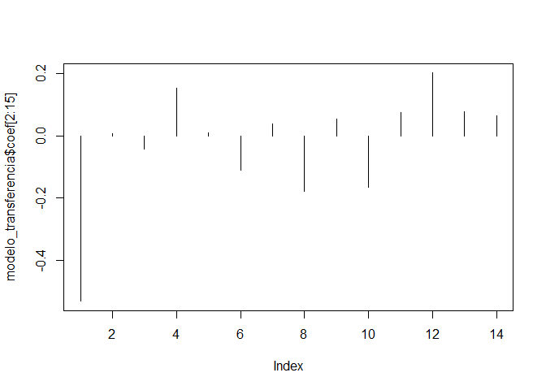

```
##
## Call:
## arimax(x = colgate_134_diff, order = c(0, 1, 1), include.mean = TRUE, fixed = c(NA,
##     NA, 0, 0, NA), method = "ML", xtransf = crest_134_diff, transfer = list(c(1,
##     2)))
##
## Coefficients:
##           ma1   T1-AR1  T1-MA0  T1-MA1   T1-MA2
##       -1.0000  -0.5917       0       0  -0.0501
## s.e.   0.0198   0.4683       0       0   0.0859
##
## sigma^2 estimated as 0.003694:  log likelihood = 177.17,  aic = -348.35
##
## Training set error measures:
##                      ME       RMSE        MAE      MPE     MAPE      MASE
## Training set 0.00211709 0.06054445 0.04610623 109.7694 113.5165 0.6000219
##                    ACF1
## Training set -0.4020392
```

En el gráfico anterior podemos interpretar que para Colagte, el primer periodo a partir de la semana 135, se observa que como se ha producido una caida en su cotización de Colgate mientras que puede haber coincidido con el alza de Crest.